# Team X - Lab 2

## Specify and fit models

The model I fit has unequal U (different population growth rates), diagonal and equal R (equal variances, no correlations), equalvarcov Q (identical variance and covariance). This model can be written in matrix form as follows:

```r
mod_list = list(
  U = "unequal",
  R = "diagonal and equal",
  Q = "equalvarcov"
)

library(MARSS)
fit = MARSS(data, model = mod_list, control = list(maxit = 10000))
```

```
## Success! abstol and log-log tests passed at 266 iterations.
## Alert: conv.test.slope.tol is 0.5.
## Test with smaller values (<0.1) to ensure convergence.
##
## MARSS fit is
## Estimation method: kem
## Convergence test: conv.test.slope.tol = 0.5, abstol = 0.001
## Estimation converged in 266 iterations.
## Log-likelihood: -227.2247
## AIC: 504.4494   AICc: 507.7322
##
##                          Estimate
## R.diag                    0.08103
## U.X.Clearwater River     -0.02385
## U.X.Lochsa/Selway         0.00528
## U.X.Clearwater/Lolo      -0.00299
## U.X.Grande Ronde River   -0.03359
## U.X.Joseph Creek         -0.02764
## U.X.Asotin Creek         -0.04810
## U.X.Tucannon River        0.02145
## U.X.Little Salmon River  -0.01967
## U.X.Fork Salmon River    -0.00710
## U.X.Fork Salmon/Secesh   -0.01529
## U.X.Salmon/Panther       -0.00520
## Q.diag                    0.35659
## Q.offdiag                 0.34824
## x0.X.Clearwater River     7.69038
## x0.X.Lochsa/Selway        6.91228
## x0.X.Clearwater/Lolo      7.01319
## x0.X.Grande Ronde River   8.48899
## x0.X.Joseph Creek         8.21413
## x0.X.Asotin Creek         7.22930
## x0.X.Tucannon River       5.78522
## x0.X.Little Salmon River  6.78293
## x0.X.Fork Salmon River    7.31120
## x0.X.Fork Salmon/Secesh   6.76782
## x0.X.Salmon/Panther       7.85460
## Initial states (x0) defined at t=0
##
## Standard errors have not been calculated.
## Use MARSSparamCIs to compute CIs and bias estimates.
```

Here I’m appending the fitted values to the data, so the missing values in certain years can be filled in with the estimated states.

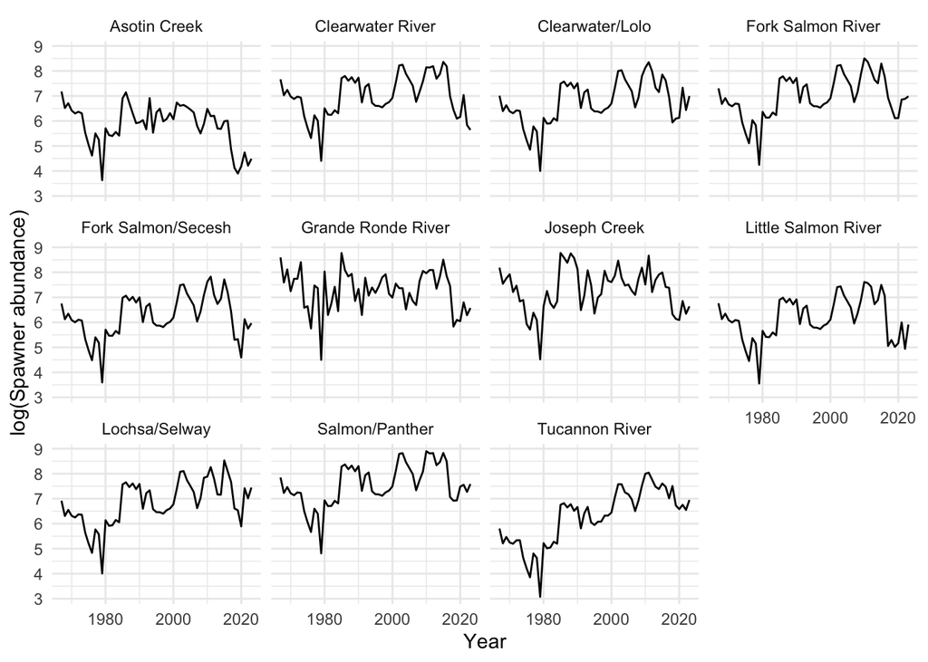

```r
states = fit$states

# Replace NAs with estimated states
data[is.na(data)] = states[is.na(data)]

# Plot completed data
data %>%
  as.data.frame() %>%
  rownames_to_column() %>%
  pivot_longer(cols = -rowname,
               names_to = "year",
               values_to = "value") %>%
  rename(region = rowname) %>%

  ggplot(aes(x = as.numeric(year), y = value)) +
  geom_line() +
  facet_wrap(~region) +
  theme_minimal() +
  xlab("Year") +
  ylab("log(Spawner abundance)")
```

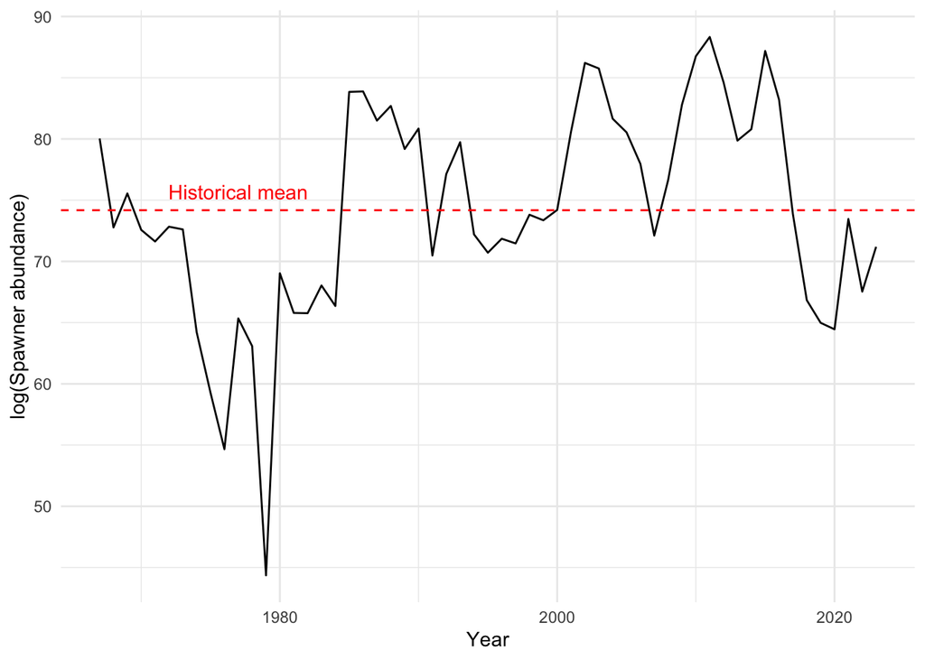

```r
# get mean value over the years
historical_mean = data %>%
  as.data.frame() %>%
  rownames_to_column() %>%
  pivot_longer(cols = -rowname,
               names_to = "year",
               values_to = "value") %>%
  group_by(year) %>%
  summarise(value = sum(value, na.rm = TRUE)) %>%
  summarise(mean = mean(value, na.rm = TRUE))

data %>%
  as.data.frame() %>%
  rownames_to_column() %>%
  pivot_longer(cols = -rowname,
               names_to = "year",
               values_to = "value") %>%
  rename(region = rowname) %>%
  group_by(year) %>%
  summarise(value = sum(value, na.rm = TRUE)) %>%

  ggplot(aes(x = as.numeric(year), y = value)) +
  geom_line() +
  theme_minimal() +
  geom_hline(yintercept = historical_mean$mean, linetype = "dashed", color = "red") +
  xlab("Year") +
  ylab("log(Spawner abundance)") +
  annotate("text", x = 1977, y = historical_mean$mean + 1.5,
           label = "Historical mean", color = "red")
```

# Question 2: Evaluate support for the major population groups. Are the populations in the groups more correlated than outside the groups?

## Ben Makhlouf

Wrangle the data.

[figure not shown]

```r
library(dplyr)
# Our group was assigned only Steelhead.
SteelheadAll<- esa.salmon %>%
  filter(species=="Steelhead")


# Plot all Summer Steelhead faceted by ESA group and log transformed value
library(ggplot2)

Stl_plot<- SteelheadAll %>%
  mutate(log_value=log(value)) %>%
  ggplot(aes(x=spawningyear, y=log_value, color = run)) +
  geom_point() +
  facet_wrap(~esapopname) +
  theme_bw() +
  labs(title="Summer Steelhead by ESA group", x="Year", y="Log Abundance")


print(Stl_plot)
```

```r
# Step 1: Start with your full dataset
Stl <- SteelheadAll

# Step 2: Create region and run labels BEFORE pivoting
Stl <- Stl %>%
  mutate(
    region = case_when(
      grepl("Lower", esapopname) ~ "Lower",
      grepl("Middle", esapopname) ~ "Middle",
      grepl("Upper", esapopname) ~ "Upper",
      TRUE ~ "Unknown"
    ),
    run_timing = case_when(
      grepl("summer", esapopname, ignore.case = TRUE) ~ "Summer",
      grepl("winter", esapopname, ignore.case = TRUE) ~ "Winter",
      TRUE ~ "Unknown"
    )
  )

# Filter out Unknown categories
Stl <- Stl %>%
  filter(region != "Unknown" & run_timing != "Unknown")

# Clean up the names (simplify for pivoting)
Stl$esapopname <- gsub("Steelhead", "", Stl$esapopname)
Stl$esapopname <- gsub("- summer", "", Stl$esapopname)
Stl$esapopname <- gsub(" - winter", "", Stl$esapopname)


# Store lookup table for region/run AFTER cleaning names
meta_info <- Stl %>%
  select(esapopname, region, run_timing) %>%
  distinct()

# Pivot wider to population x year
Stl_wide <- Stl %>%
  select(spawningyear, esapopname, value) %>%
  pivot_wider(names_from = esapopname, values_from = value)

# Save years and transpose
Years <- Stl_wide$spawningyear
Stl_mat <- Stl_wide %>%
  select(-spawningyear) %>%
  as.matrix() %>%
  t()

# Assign years as column names and reorder by year
colnames(Stl_mat) <- Years
Stl_mat <- Stl_mat[, order(as.numeric(colnames(Stl_mat)))]
#Make sure all NaN are NA
Stl_mat[is.nan(Stl_mat)] <- NA

Data<- Stl_mat

#Create vectors for regions and run timings
region_vec <- meta_info$region[match(rownames(Stl_mat), meta_info$esapopname)]
run_vec <- meta_info$run_timing[match(rownames(Stl_mat), meta_info$esapopname)]

n_pops <- nrow(Stl_mat)


# For Region-based model
regions <- unique(region_vec)
n_regions <- length(regions)
Z2 <- matrix(0, n_pops, n_regions)
for (i in 1:n_pops) {
  region_index <- which(regions == region_vec[i])
  Z2[i, region_index] <- 1
}

# For Run-based model
runs <- unique(run_vec)
n_runs <- length(runs)
Z3 <- matrix(0, n_pops, n_runs)
for (i in 1:n_pops) {
  run_index <- which(runs == run_vec[i])
  Z3[i, run_index] <- 1
}
```

```r
# ==========================================
# Compare via AIC and AICc
# ==========================================

# Collect all AICc values
model_names <- c("1. All populations same (H1)",
                "2. Region-based (H2)",
                "3. Run-based (H3)",
                "4. Region + Unequal Q",
                "5. Run + Unequal Q")

AICc_values <- c(fit1$AICc, fit2$AICc, fit3$AICc, fit4$AICc, fit5$AICc)
min_AICc <- min(AICc_values)
delta_AICc <- AICc_values - min_AICc

# Create and print the simple comparison table
comparison_table <- data.frame(
  Model = model_names,
  AICc = round(AICc_values, 2),
  delta_AICc = round(delta_AICc, 2)
)

# Sort by AICc
comparison_table <- comparison_table[order(comparison_table$AICc), ]

# Print the simple comparison table
cat("\n============ MODEL COMPARISON TABLE ============\n")
```

```
##
## ============ MODEL COMPARISON TABLE ============
```

```r
print(comparison_table, row.names = FALSE)
```

```
##                         Model     AICc delta_AICc
##            5. Run + Unequal Q 20941.71       0.00
##             3. Run-based (H3) 20963.01      21.30
##  1. All populations same (H1) 20992.67      50.96
##          2. Region-based (H2) 21041.15      99.44
##         4. Region + Unequal Q 21045.95     104.25
```

# DISCUSSION

I employed several MARSS models to analyze population dynamics of Steelhead salmon across different regions and run timings. Five candidate models were developed to test competing hypotheses about the underlying structure of population dynamics. Our results provide strong support for run timing as the primary factor structuring Steelhead populations, with the run-based model that incorporated heterogeneous process variance (Model 5) outperforming all other models. The substantial difference in AICc values (ΔAICc > 21) between this model and the next best alternative provides compelling evidence that Summer and Winter run populations experience different environmental influences and respond differently to ecosystem changes. The models differed in their assumptions about population structure (Z matrix) and process error variance (Q matrix). Model 1 represented the simplest case, treating all populations as reflecting a single underlying state with uniform process variance. Models 2 and 3 introduced structure based on either geographic regions or run timing, respectively, while maintaining equal process variance across groups. Models 4 and 5 expanded upon the previous models by allowing for heterogeneous process variance between groups. The superior performance of Model 5 indicates that not only do Summer and Winter steelhead populations follow distinct trends, but they also experience different levels of environmental stochasticity.

# Question 3: Evaluate relationships between steelhead spawner abundance and climate covariates

## Anna Sulc

```r
library(tidyverse)
library(dplyr)
library(zoo)
```

```r
library(MARSS)

load(file.path(here::here(), "Lab-2", "Data_Images", "np_climate.RData"))
load(file.path(here::here(), "Lab-2", "Data_Images", "esa-salmon.rda"))

years <- which(np_climate_seasonal$year %in% 2000:2024)
spring_pdo <- np_climate_seasonal$pdo.spring[years]
cmat <- matrix(spring_pdo, nrow=1)
cmat
```

```
##            [,1]       [,2]   [,3]      [,4]  [,5]      [,6]       [,7]  [,8]
## [1,] -0.4936667 -0.8706667 -0.855 0.2236667 0.101 0.6923333 -0.1836667 -0.09
##           [,9]     [,10]      [,11]     [,12]  [,13]      [,14]     [,15]
## [1,] -1.490333 -1.181667 -0.2626667 -1.055333 -1.271 -0.6396667 0.4516667
##          [,16]    [,17] [,18]      [,19] [,20]  [,21] [,22]  [,23]     [,24]
## [1,] 0.6253333 1.264333 0.337 -0.5083333  0.22 -0.785 -1.57 -1.748 -2.190333
##          [,25]
## [1,] -2.347333
```

```r
esu <- unique(esa.salmon$esu_dps)
esunum <- which(esu == "Steelhead (Upper Columbia River DPS)")
esuname <- esu[esunum]

dat <- esa.salmon %>%
  subset(esu_dps == esuname) %>% # get only this ESU
  mutate(log.spawner = log(value)) %>% # create a column called log.spawner
  dplyr::select(esapopname, spawningyear, log.spawner) %>% # get just the columns that I need
  pivot_wider(names_from = "esapopname", values_from = "log.spawner") %>%
  column_to_rownames(var = "spawningyear") %>% # make the years rownames
  as.matrix() %>% # turn into a matrix with year down the rows
  t() # make time across the columns
# MARSS complains if you don't do this


dat[is.na(dat)] <- NA
# Clean up rownames
tmp <- rownames(dat)
tmp <- stringr::str_replace(tmp, "Steelhead [(]Upper Columbia River DPS[)]", "")
tmp <- stringr::str_replace(tmp, "River - summer", "")
tmp <- stringr::str_trim(tmp)
rownames(dat) <- tmp

names(np_climate_seasonal)
```

```
##  [1] "year"           "pna.fall"       "pna.spring"     "pna.summer"
##  [5] "pna.winter"     "pna.annual"     "epo.fall"       "epo.spring"
##  [9] "epo.summer"     "epo.winter"     "epo.annual"     "wp.fall"
## [13] "wp.spring"      "wp.summer"      "wp.winter"      "wp.annual"
## [17] "censo.fall"     "censo.spring"   "censo.summer"   "censo.winter"
## [21] "censo.annual"   "whwp.fall"      "whwp.spring"    "whwp.summer"
## [25] "whwp.winter"    "whwp.annual"    "oni.fall"       "oni.spring"
## [29] "oni.summer"     "oni.winter"     "oni.annual"     "meiv2.fall"
## [33] "meiv2.spring"   "meiv2.summer"   "meiv2.winter"   "meiv2.annual"
## [37] "pdo.fall"       "pdo.spring"     "pdo.summer"     "pdo.winter"
## [41] "pdo.annual"     "ipotpi.fall"    "ipotpi.spring"  "ipotpi.summer"
## [45] "ipotpi.winter"  "ipotpi.annual"  "np.fall"        "np.spring"
## [49] "np.summer"      "np.winter"      "np.annual"      "pacwarm.fall"
## [53] "pacwarm.spring" "pacwarm.summer" "pacwarm.winter" "pacwarm.annual"
## [57] "gmsst.fall"     "gmsst.spring"   "gmsst.summer"   "gmsst.winter"
## [61] "gmsst.annual"
```

## Research Question:

I chose to pursue the question of which covariate and/or their combination best explains variability in the salmon model. When thinking about the problem of what covariate performs best and why, it seemed difficult to say which may be the most likely to perform best using literature and my knowledge. Additionally, some ocean and climate processes interact, further complicating impacts. Finally, there is a seasonal effect. Depending on the life stage and the time that the oscillation/impact occurs, effects may be different. As a result, I formulated the following questions:

1. Which series of covariates explain the most variance?

   A. What set of covariates explains the run size best overall

   B. What covariates perform best for each season? Does this make sense?

As this exercise was also a test of whether my expectation that using “expert” knowledge in some cases may be flawed (we expect things to work differently than they do) I also chose a few preliminary hypotheses that my combination approach would test:

1. More complex models (2+ covariates) will dominate the upper ranks as they are more informed than other models (single or null)
2. The PDO and GMSST covariates will remain at the top of the series across seasons (maybe ENSO as well) as they are global patterns that impact all parts of the year unlike winter/summer effects
3. For seasons, the localized covariates will be most influential as they will have direct but important, short term impacts.

## Method

### Covariate Choices

It was possible to run all combinations for all seasons but this resulted in hundreds of combinations (12 covariates, step wise combinations for each and 4 seasons). As a result I made a targeted selection of 8 covariates I felt may be the most influential for my questions and my tests.

1. PNA - Directly specific to the North Pacific and strong influence for impacts on salmon through river flow and snowpack (breeding stage)
2. EPO - Affects early life stage survival where salmon are more sensitive and vulnerable.
3. ONI - Reduces survival through prey abundance. Is a largescale event so may impact all seasons thus being more influential
4. CENSO - Included because I was curious if these multiple El Nino indices will compete or not.
5. WHWP - Included to see if I can get one covariate failing consistently. Doesn’t seem strongly related
6. PDO - Like El Nino - this is a large scale event that will impact all seasons.
7. GMSST - Another large scale pattern. It also creates longterm conditions and unlike PDO or ENSO will be persistent across the timeseries or increasing over time.
8. NP - Like the NPA, it is a localized effect.

First, I chose to divide the covariate names in to two components: the mechanism and the season. I was interested in whether (1) certain seasons explain variability better overall and (2) whether the same covariate combination performs best across all time series and all seasons. I found all combinations of covariates and seasons (for this lab a smaller subset for testing and demonstration)

```r
seasons <- c("spring","summer", "fall","winter")
clim_var <- c("pna","epo","oni", "censo","whwp", "pdo","gmsst", "np")

# Create all combinations
combo_df <- expand.grid(season = seasons, variable = clim_var)

# Combine with "." separator
combo_names <- paste( combo_df$variable,combo_df$season, sep = ".")


all_combos <- NULL
for (i in 1:length(seasons)){

    temp <- seasons[i]
    matches <- combo_names[grepl(temp, combo_names)]

    season_combos <- list()

    for(m in 1:length(matches)) {
    combos <- combn(matches, m, simplify = FALSE)
    season_combos[[paste0("size_", m)]] <- combos
    }

    all_combos[[temp]] <- season_combos

}
```

Then, I wrote a loop that would work through the list and fit step wise combinations of all covariates. I first wrote a series of subscripts that I tested before building the large nested loop as the indexing was tricky with seasons and combination names.

The loop works through each season, creating a respective sub list before looping through all combinations and fitting a MARSS model for each. The structure of MARSS models was kept the same to allow for cross comparison. Covariates were weighted equally to allow for exploration.

```r
#To explain model structure here is the model written out by hand before using the commands in the loop
# We have 4 regions, this matrix assigns the drift or the process depending on the region. We assume it is not the same as regions vary
# U = matrix(c(u1, u2, u3, u4), nrow = 4)
#
# #We assume variance is the same because they are all salmon populations so should behave similarly
# R = diag(sigma^2, 4)
#
# #Process error is different for each region as they are not the same
# Q = diag(c(q1, q2, q3, q4))
#
# #A matrix with # rows being the # of covariates and columns years
# c <- var_matrix
```

```r
years <- which(np_climate_seasonal$year %in% colnames(dat))


all_cmat <- list()
AIC_results <- list()
dropped_fits <- list()  #for failed/unconverged models

# Loop over each combination size group
for (i in 1:length(seasons)) {
  season <- seasons[i]
  season_combos <- all_combos[[i]]

  for (j in seq_along(season_combos)) {

  combo_group_name <- names(season_combos)[j]     # e.g., "size_1"
  combo_group <- season_combos[[j]]               # list of combinations of that size

  combo_matrices <- list()  # Reset for each group

  # Loop over each combination within the group
  for (v in seq_along(combo_group)) {

    var_names <- combo_group[[v]]  # vector of variable names in this combo
    print(paste("Processing:", paste(var_names, collapse = "+")))  # Debug info

    # Extract climate data rows and build matrix
    var_matrix <- do.call(rbind, lapply(var_names, function(var) {
      covs <- np_climate_seasonal[[var]][years]
      na.approx(covs, rule=2)
    }))



    # Set row names for clarity
    rownames(var_matrix) <- var_names

    # Create a name for the combination (e.g., "oni.spring+pdo.spring")
    combo_name <- paste(var_names, collapse = "+")

    # Store in list
    combo_matrices[[combo_name]] <- var_matrix


    #MARSS Part
    mod.list <- list(
      U = "unequal",
      R = "diagonal and equal",
      Q = "diagonal and unequal",
      c =  var_matrix,
      C = "unequal"
    )

    fit <- MARSS(dat, model=mod.list)

    if (fit$convergence == 0) {
    AIC_results[[combo_name]] <- AIC(fit)
    }
    else{
      dropped_fits[[combo_name]] <- fit
      combo_matrices[[combo_name]] <- NULL
    }

    #Cool troubleshooting trick!! Remember for chapter.
    # if (inherits(fit, "try-error")) {
    #   AIC_results[[combo_name]] <- NA  # mark failure
    # } else {
    #   AIC_results[[combo_name]] <- AIC(fit)
    # }

  }

  #Crashes otherwise
  if (is.null(all_cmat[[season]])) {
    all_cmat[[season]] <- list()
  }


  all_cmat[[season]][[combo_group_name]] <- combo_matrices
  }
}
```

[output not shown]

[output cut: 52059 more lines]

[output not shown]

```r
#If loading the results for grading. File pushed to team folder.
readRDS(file.path(here::here(), "Lab-2", "Team-3", "AIC_Lab2.Rdata"))
```

```
##                                                                     combo
## 1                                              epo.fall+whwp.fall+np.fall
## 2                                                        epo.fall+np.fall
## 3                                                                 np.fall
## 4                                                        pdo.fall+np.fall
## 5                                                        pna.fall+np.fall
## 6                                 censo.fall+whwp.fall+gmsst.fall+np.fall
## 7                                              whwp.fall+pdo.fall+np.fall
## 8                                            whwp.fall+gmsst.fall+np.fall
## 9                                   epo.fall+censo.fall+whwp.fall+np.fall
## 10                                                     gmsst.fall+np.fall
## 11                                    pna.fall+epo.fall+whwp.fall+np.fall
## 12                                              epo.fall+pdo.fall+np.fall
## 13                                              epo.fall+oni.fall+np.fall
## 14                                                     censo.fall+np.fall
```

[output cut: 927 more lines]

Following fitting I ranked the results first overall and then by season. I first made the results in to a data frame to make them easier to work with and then moved on to ranking them.

```r
aic_rank <- data.frame(
  combo = names(AIC_results),
  AIC = unlist(AIC_results),
  stringsAsFactors = FALSE
)

aic_rank$overall_rank <- rank(aic_rank$AIC, ties.method = "first")
aic_rank <- aic_rank[order(aic_rank$overall_rank), ]

rownames(aic_rank)<- NULL
```

For the seasonal component I had to draw the seasonal names back out. This could have been done in the large loop but seemed tricky to do at this stage. I have been trying to use the apply functions more frequently so tried to get practice here.

```r
#Code extracting the season and the respective ranks

# This function says we are looking for the season that matches the same in the seasons #vector and then
get_season <- function(combo_name, season_list) {
  matched <- season_list[sapply(season_list, function(season) grepl(season, combo_name))]
  if (length(matched) > 0) return(matched[1]) else return(NA)
}

aic_rank$season <- sapply(aic_rank$combo, get_season, season_list = seasons)

seasonal_ranks <- list()

for (s in 1:length(seasons)){
  season <- seasons[s]
  temp <- aic_rank[which(aic_rank$season==season),]
  temp$seas_rank <- rank(temp$AIC, ties.method = "first")
  temp <- temp[order(temp$seas_rank), ]
  rownames(temp)<- NULL
  seasonal_ranks[[season]] <- temp
}

seasonal_ranks
```

```
## $spring
##                                                                     combo
## 1                                                  censo.spring+np.spring
## 2              oni.spring+censo.spring+whwp.spring+gmsst.spring+np.spring
## 3                           oni.spring+censo.spring+whwp.spring+np.spring
## 4                                      censo.spring+whwp.spring+np.spring
## 5                                       pna.spring+censo.spring+np.spring
## 6                                       epo.spring+censo.spring+np.spring
## 7                                                 censo.spring+pdo.spring
## 8                                                             whwp.spring
## 9                                       censo.spring+pdo.spring+np.spring
## 10                                                           censo.spring
## 11                                                   oni.spring+np.spring
## 12                                                  whwp.spring+np.spring
## 13                          pna.spring+censo.spring+whwp.spring+np.spring
```

[output cut: 940 more lines]

Finally, I wanted a null model for AIC comparisons - did adding covariates actually improve model performance?

```r
mod.listnull <- list(
  U = "unequal",
  R = "diagonal and equal",
  Q = "diagonal and unequal")

fitnull <- MARSS(dat, model=mod.listnull)
```

```
## Success! abstol and log-log tests passed at 304 iterations.
## Alert: conv.test.slope.tol is 0.5.
## Test with smaller values (<0.1) to ensure convergence.
##
## MARSS fit is
## Estimation method: kem
## Convergence test: conv.test.slope.tol = 0.5, abstol = 0.001
## Estimation converged in 304 iterations.
## Log-likelihood: -154.5953
## AIC: 335.1906   AICc: 337.6012
##
##                             Estimate
## R.diag                       0.08492
## U.X.Entiat                   0.00213
## U.X.Methow                  -0.00557
## U.X.Okanogan                -0.00920
## U.X.Wenatchee               -0.02427
## Q.(X.Entiat,X.Entiat)        0.14095
## Q.(X.Methow,X.Methow)        0.14800
## Q.(X.Okanogan,X.Okanogan)    0.14483
## Q.(X.Wenatchee,X.Wenatchee)  0.38490
## x0.X.Entiat                  5.57099
## x0.X.Methow                  7.40887
## x0.X.Okanogan                7.10616
## x0.X.Wenatchee               8.06274
## Initial states (x0) defined at t=0
##
## Standard errors have not been calculated.
## Use MARSSparamCIs to compute CIs and bias estimates.
```

```r
AIC(fitnull)
```

```
## [1] 335.1906
```

## Results

The results of my analysis confirmed several hypotheses and surprised me in several aspects.

First, only 55 models performed better than the null model. This suggests that in all other cases, covariates did not improve the ability of the MARSS model to explain variability in the system. Initially, I expected that adding any additional environmental effect would improve model performance. However, this result goes to show, that in a large number of cases, there was no relationship between the environmental effect and salmon runs.

Second, I was able to show that season does matter - all top models for the global set were fall models suggesting that this seasons best explained the variability in salmon runs while all others seemed to alternate in performance. However, while the dominant process/covariate in the global ranking was NP, it was not the case for other seasons. In the case of summer, the best performing model was epo.summer+censo.summer+gmsst.summer perhaps because the effects of these processes are most important/visible at this time of year. A final and comforting observation for my intuition was that the EPO dominated the winter model combinations. As a winter process this was expected and reinforced my theory that seasonal combinations would and should differ.

The results for expected impact of covariates varied. My expectation the a local effect will be more important than global effects was confirmed by the North Pacific Index being present in all of the tops 30 models. Retrospectively, this makes sense given that salmon migrate northward to the Bering Sea/Aleutian Islands to feed and any oceanographic features will directly impact them. Beyond the NP effect, no other covariate was observed to be as significant across all seasons and models. This second observation surprised me as I would have expected something like ENSO or PDO to produce large enough impacts for a long period of time to significantly impact a population. Instead, it seems that local processes drive changes in salmon runs.

## Discussion

While I was not able to test all covariate combinations as I had initially wanted, I was able to make some inferences and answer some of the questions I was curious about. First, seasons made a significant difference in my results. Covariates did not dominate all seasons and varied significantly.

Steps I would have liked to pursue if I had more time would have been **a full exploration of all covariates, the regional analysis and perfecting certain troubleshooting or model performance components**. The full exploration would have allowed for me to truly explore relationships between effects. One issue I realized towards the end of my analysis was that a correlation exclusion process would have been useful to cut down on combinations - two ENSO events in one model are redundant and statistically incorrect. Similarly, while different, the NPA and NP effects may be tied to one oceanographic process. However, given time and the length of runs I chose to keep my results and continue as this was an exploratory analysis.

Second, exploring regional effects by plotting results across regions and experimenting with model structure would have been an additional step. Do models fit one region better than others? Are all regions impacted by covariates the same way? Perhaps some covariate combinations affect one region while others do not observe these effects or see them in different seasons.

Finally, while I included a few diagnostics components (excluding non converged models, avoiding crashes, etc), finding a way to present results visually and demonstrate differences in performance would have been exciting/beneficial. Another component I wished I could have explored would have been changing model structure to see how model performance changed or attempting to mix different seasons to see if there is a “best” model that captures impacts on different parts of the life stage by different covariates.

## Team Member Contributions

All team members participated in formulating the lab questions, wrangling the data and exploring the data set to create a strategy for analysis. Then, one lab task was assigned to each lab member. We had one meeting to check in on progress and provide support for others if necessary and share results/communicate findings. Matheus created estimates of spawner abundance for all missing years, Ben explored the major population groups and Anna focused on the climate covariates and their correlation with run size.